# Lab3

Author

Jane He and Monica Orme

Published

February 2, 2024

# Goals for Today

- Clarifying Questions from Lab 2
- Refreshing R Basics
- Descriptive Statistics in R: How to?
- Compiling Reports from R Scripts
- Practice with Lab Activity

# Lab 2 Recap

Concepts/skills we learned about:

- Setting up Directories
  - Directories –> Folders
  - Path –> Address to your folder
  - Working Directory –> Default folder that R is currently using
    - Set working directories in R to a folder that contains your lab files inputting your folder’s path into `setwd()`
    - Always check what your current working directory is using `getwd()`
- Importing datasets
  - Use `read.csv()` for csv (.csv) files and `read.table()` for text (.txt) files
  - The resulting object from importing a dataset in R is a **dataframe**
    - It consists of rows and columns. Typically, each row is an observation and each column is a variable.
- Graphical Displays
  - Use bar charts for categorical data
    - Uses frequencies or relative frequencies
  - Use histograms, dot charts, or stem-leaf plots for numeric data

# R Basics Refresher

## Working Directory

Once again, **both you and R** need to know where to find files.

We talked about what is a directory, a path, and a working directory last week. You can refer back to supplementary materials from Lab 2 (linked in weekly recap announcement) for detailed definitions.

For Lab 3, we will focus on setting up working directory.

### Working Directory: Steps

1. Decide on the directory that you want R to work in
   - Tells R where is the destination, which is the working directory to set
     - E.g. a folder named Lab3
2. Find the path to the directory from step 1
   - Gives the address to R, so that it knows the route to destination
     - E.g. “/Users/jane/Documents/GitHub/PSC103A/Lab3”
3. Pass down the path from step 2 as an argument to `setwd()` function
   - Asks R to start routing to its given destination

     ```r
     setwd(dir = "/Users/jane/Documents/GitHub/PSC103A/Lab3") # Example for a Mac
     setwd(dir = "C:/Users/Monica/OneDrive/st - PSC 103A/Discussions-Labs/Lab Slides-Code") # Example for a PC
     ```

4. Call `getwd()` to verify the working directory
   - Has R report back on its arrival at the destination

     ```r
     getwd() # Same command on Mac and PC
     ```

     ```
     [1] "/Users/jane/Documents/GitHub/PSC103A/Lab3"
     ```

## Data Files

We talked about different data files format last week. You can refer back to supplementary materials from Lab 2 (linked in weekly recap announcement) for use cases.

For this course, we focus on .txt or .csv formats.

In practice, you can go with any format of your preference. However, make sure to use the R function suitable to the chosen format.

### Importing Dataset: Steps

1. Decide on the data file and its format to import
2. Find the path of the chosen data file
3. Pass down the path from step 2 as an argument to R function
   - Call `read.table()` or `read.csv()` based on chosen format
   - Use the full or relative path based on the location of file
   - Always should store our imported dataset as a R object

For examples:

With .txt file, we can use `read.table()`:

```r
# create an object with self-explanatory name
lab3_data_txt <- read.table(
  file = "LearningModule3/lab2data.txt",
# specify the directory of the file
## I am in my working directory
### so the relative path is sufficient
  header = TRUE,
# to recognize the first row as variable names
  stringsAsFactors = TRUE)
# to convert character values into factors
```

With .csv file, we can use `read.csv()`:

```r
# create an object with self-explanatory name
lab3_data_csv <- read.csv(
  file = "/Users/jane/Documents/GitHub/PSC103A/Lab3/LearningModule3/lab2data.csv",
# specify the directory of the file
## a full path will always work
### but especially when you don't set up working directory
  header = TRUE,
# to recognize the first row as variable names
  stringsAsFactors = TRUE)
# to convert character values into factors
```

### Checking Dataset: Steps

1. Take a quick look at the R Environment. Do you see the dataset show up?

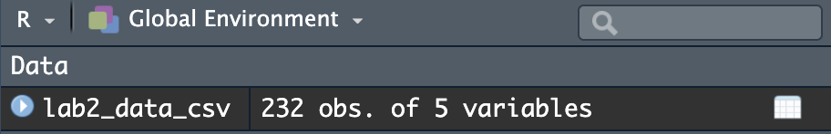

2. Quickly check the behavior of our dataset with `head()`

   ```r
   head(lab3_data_csv, n = 2) # "n" specifies how many rows we want to print out, omit it will return 6 rows by default
   ```

   ```
   # A tibble: 2 × 5
     biosex height_in weight_lbs age_yr ed_cmplt
     <fct>      <dbl>      <dbl>  <dbl> <fct>
   1 MALE        72.2       146.   20   College2YR
   2 FEMALE      61.5       104.   22.7 College4YR
   ```

3. Check the data types of the variables in our dataset

   Check all variables by using `str()`:

   ```r
   str(lab3_data_csv) # specify the object we want to check
   ```

   ```
   'data.frame':   232 obs. of  5 variables:
    $ biosex    : Factor w/ 2 levels "FEMALE","MALE": 2 1 2 2 1 2 2 1 1 1 ...
    $ height_in : num  72.2 61.5 68.4 69.6 62.3 67.5 69.9 58.9 57.9 NA ...
    $ weight_lbs: num  146 104 163 152 118 ...
    $ age_yr    : num  20 22.7 25.7 22.9 23.4 20.2 20.1 23.1 30.6 28.2 ...
    $ ed_cmplt  : Factor w/ 5 levels "College2YR","College4YR",..: 1 2 4 2 2 1 1 2 5 5 ...
   ```

   Check one variable by using `class()` with `$`:

   ```r
   # specify the object and variable wanted to check
   class(lab3_data_csv$biosex)
   ```

   ```
   [1] "factor"
   ```

   ```r
   # specify the object and variable wanted to check
   class(lab3_data_csv$age_yr)
   ```

   ```
   [1] "numeric"
   ```

## R Packages

We briefly touched on R packages before. You can refer back to supplementary materials from Lab 1 (linked in weekly recap announcement).

When the Base R functions are not sufficient for our purposes, we can use functions from R packages developed by the R community.

For today’s lab, we look at two packages: `psych` and `Hmisc`. Both have functions that can give us descriptive statistics, but also have their own advantages.

### Accessing Packages: Steps

1. Decide on the package in need
2. Install the package via `install.packages()`

   ```r
   install.packages("psych") # specify the package name
   ```

   - Typically, we only need to install the package(s) once, then we can comment this command out, especially when compiling reports. However, we will need to re-install the package(s) after updating R and RStudio.
3. Load in the installed package via `library()`

   ```r
   library("psych") # specify the package name
   ```

   - Asks R to open and read the installed package
     - Simply having the package installed doesn’t equal to telling R to open the pakcage. We should never comment out this command out.
4. Quickly check the package is loaded in the “Packages” tab. Do you see a checked box?

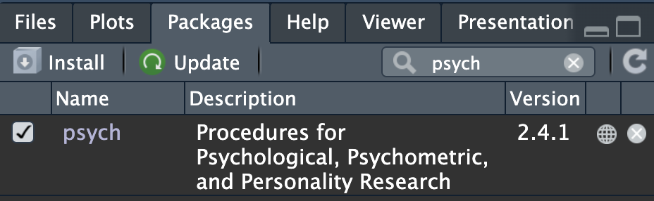

### Bonus Tip: Package Conflicts

There are a couple of R packages has different functions under the same name. Those functions do not work the same or return identical outputs.

- A potential issue that we might run into with loading in those packages in the same R script is package conflicts.
- That means, though the function called is able to run, we might not be calling it from the intended package.

Let’s look at an example.

#### Package Conflicts: Example

- In the `psych` package that we installed and loaded in earlier, there is a function named `describe()`. It outputs many descriptive statistics covered in this course:

  ```r
  describe(lab3_data_csv) # pass in the sotred data frame
  ```

  ```
  # A tibble: 5 × 13
     vars     n   mean     sd median trimmed   mad   min   max range   skew
    <int> <dbl>  <dbl>  <dbl>  <dbl>   <dbl> <dbl> <dbl> <dbl> <dbl>  <dbl>
  1     1   232   1.49  0.501    1      1.48  0      1     2     1   0.0514
  2     2   228  63.8   4.63    63.5   63.7   6.08  54    73.4  19.4 0.161
  3     3   230 132.   20.0    130.   132.   25.9   88   172.   83.8 0.0363
  4     4   229  24.2   3.19    24.3   24.0   2.22  19.4  32.2  12.8 0.460
  5     5   232   2.90  1.40     3      2.88  1.48   1     5     4   0.0444
  # ℹ 2 more variables: kurtosis <dbl>, se <dbl>
  ```

- Now let’s install and load in the `Hmisc` package, which also have a function called `describe()`. It shows number of missing values and unique values in dataset:

  ```r
  # install.packages("Hmisc") # specify package name
  # I commented it out after installing and before compiling
  ```

  ```r
  library("Hmisc") # specify package name
  describe(lab3_data_csv) # pass in the sotred data frame
  ```

  ```
  lab3_data_csv

   5  Variables      232  Observations
  --------------------------------------------------------------------------------
  biosex
         n  missing distinct
       232        0        2

  Value      FEMALE   MALE
  Frequency     119    113
  Proportion  0.513  0.487
  --------------------------------------------------------------------------------
  height_in
         n  missing distinct     Info     Mean      Gmd      .05      .10
       228        4      120        1    63.78    5.309    57.73    58.17
       .25      .50      .75      .90      .95
     59.80    63.50    67.82    69.93    70.80

  lowest : 54   55.9 56.4 56.5 56.9, highest: 72.5 72.7 72.8 73.2 73.4
  --------------------------------------------------------------------------------
  weight_lbs
         n  missing distinct     Info     Mean      Gmd      .05      .10
       230        2      192        1    131.6    23.07    102.2    105.8
       .25      .50      .75      .90      .95
     114.7    129.6    149.2    157.9    161.2

  lowest : 88    94.8  95.2  95.6  95.8 , highest: 166.3 169.9 170.5 171.4 171.8
  --------------------------------------------------------------------------------
  age_yr
         n  missing distinct     Info     Mean      Gmd      .05      .10
       229        3       79        1    24.23    3.566    19.80    20.00
       .25      .50      .75      .90      .95
     22.20    24.30    25.50    29.82    30.20

  lowest : 19.4 19.5 19.6 19.7 19.8, highest: 30.9 31.5 31.6 31.9 32.2
  --------------------------------------------------------------------------------
  ed_cmplt
         n  missing distinct
       232        0        5

  Value      College2YR College4YR         HS         MA        PhD
  Frequency          51         50         39         55         37
  Proportion      0.220      0.216      0.168      0.237      0.159
  --------------------------------------------------------------------------------
  ```

#### Package Conflicts: Solution

We can see from the example that, calling functions that have the same name might return different outputs.

- This is because the order of loading in packages matters
- The functions from the package loaded later can overwrites the functions from earlier loaded package
- One way to resolve the package conflicts is the specify the package before calling function using “::” sign
- For example:

  ```r
  psych::describe(lab3_data_csv) # specify we want the function from psych package, not Hmisc
  ```

  ```
  # A tibble: 5 × 13
     vars     n   mean     sd median trimmed   mad   min   max range   skew
    <int> <dbl>  <dbl>  <dbl>  <dbl>   <dbl> <dbl> <dbl> <dbl> <dbl>  <dbl>
  1     1   232   1.49  0.501    1      1.48  0      1     2     1   0.0514
  2     2   228  63.8   4.63    63.5   63.7   6.08  54    73.4  19.4 0.161
  3     3   230 132.   20.0    130.   132.   25.9   88   172.   83.8 0.0363
  4     4   229  24.2   3.19    24.3   24.0   2.22  19.4  32.2  12.8 0.460
  5     5   232   2.90  1.40     3      2.88  1.48   1     5     4   0.0444
  # ℹ 2 more variables: kurtosis <dbl>, se <dbl>
  ```

Now we can see expected output from the `psych` package :)

# Descriptive Statistics

Descriptive statistics can provide information about the center and variability (spread) of a dataset.

- For Categorical Data
  - Frequency, Relative Frequency
- For Numeric Data
  - Center: Mean, Median, Trimmed Mean (when there are outliers)
  - Variability: Variance, Standard Deviation, Range, Interquartile Range

## Descriptive Statistics: Categorical Data

- Frequency: The counts for each category
- Relative Frequency: **proportion of observations in a category**. It can range between 0 and 1.
  - **Relative Frequency =** $\frac{\textbf{frequency}}{\textbf{# of observations in the dataset}}$

## Descriptive Statistics: Numeric Data

- Center: what is the norm?
- Variability: how spread out is the data?

### Numeric Data: Center

- The central tendency informs us about the typical value of a variable. You can also think about it as where the scores of a numeric variable tend to cluster.
- Measures of Central Tendency:
  - Mean: the arithmetic **average**. It can be influenced by outliers.
    - $\bar{x} = \frac{\text{sum of all observations in the sample}}{\text{number of observations in the sample}}$
  - Median: the **middle** value of a numeric variable from a dataset. It is not influenced by outliers.
  - Trimmed mean: the arithmetic average after removing a certain percentage of the largest and smallest values. It is a compromise between the mean and the median.
    - The trimmed mean is preferred over the mean when there are outliers since it is less sensitive to extreme values.
  - Mode: The most **frequent** value.
- Order of Sensitivity to extreme values: Median < Trimmed Mean < Mean

## Calculating Descriptive Statistics

Descriptive statistics for datasets can be readily calculated using functions from Base R.

We will focus more on the numeric data today.

- Central Measures
  - Mean - `mean()`
  - Median - `median()`
  - Trimmed Mean - `mean(..., trim = ...)`
    - Specify the % of data to trim in the `trim` argument
      - E.g. the `trim` argument for a 10% trimmed mean is `trim = 0.1`
- Variability Measures
  - Variance - `var()`
  - Standard Deviation - `sd()`
  - Range - `range()`
  - Interquartile Range - `IQR()`
- Datasets may contain missing values. Check if they are in your dataset using the `summary()` function from Base R or the `describe()` function from the `Hmisc` package.
  - If missing values exist within a variable, remove the missing values before calculating each descriptive statistic using the option **`na.rm=TRUE`**. (Recall that R denotes missing values as `NA`)

### Calculating Descriptive Statistics: Format and Example

- Central Measures
  - General format:

    ```r
    mean(dataframe$variable, na.rm=TRUE) # mean
    median(dataframe$variable, na.rm=TRUE) # median
    mean(dataframe$variable,  trim = .10,
         na.rm = TRUE) # 10% trimmed mean
    ```

  - Example:

    ```r
    # measures of central tendency
    mean_height <- mean(lab3_data_csv$height_in,
                        na.rm=TRUE)
    median_height <- median(lab3_data_csv$height_in,
                            na.rm=TRUE)
    trimm_mean_height <- mean(lab3_data_csv$height_in,
                              trim = .10,
                              na.rm = TRUE)
    ```

    ```r
    # displaying central measures
    mean_height
    ```

    ```
    [1] 63.77763
    ```

    ```r
    median_height
    ```

    ```
    [1] 63.5
    ```

    ```r
    trimm_mean_height
    ```

    ```
    [1] 63.65543
    ```

- Variability Measures
  - General format:

    ```r
    var(dataframe$variable, na.rm = TRUE) # sample variance
    sd(dataframe$variable, na.rm = TRUE) # sample standard deviation
    range(dataframe$variable, na.rm = TRUE) # range
    IQR(dataframe$variable, na.rm = TRUE) # IQR
    ```

  - Example:

    ```r
    # measures of variability
    range_age <- range(lab3_data_csv$age_yr, na.rm = TRUE)
    variance_age <- var(lab3_data_csv$age_yr, na.rm = TRUE)
    sd_age <- sd(lab3_data_csv$age_yr, na.rm = TRUE)
    iqr_age <- IQR(lab3_data_csv$age_yr, na.rm = TRUE)
    ```

    ```r
    # displaying variability measures
    range_age
    ```

    ```
    [1] 19.4 32.2
    ```

    ```r
    variance_age
    ```

    ```
    [1] 10.20568
    ```

    ```r
    sd_age
    ```

    ```
    [1] 3.194632
    ```

    ```r
    iqr_age
    ```

    ```
    [1] 3.3
    ```

## Graphical Displays for Summarizing Data

- Categorical Data
  - Bar Plots (also called bar charts)

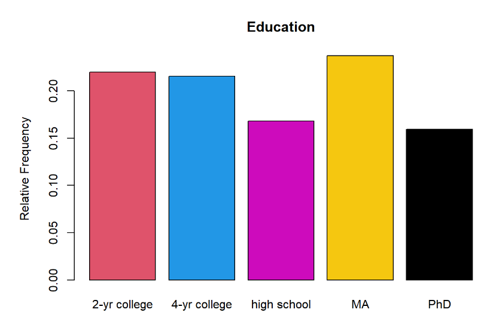

- Numeric Data
  - Histograms

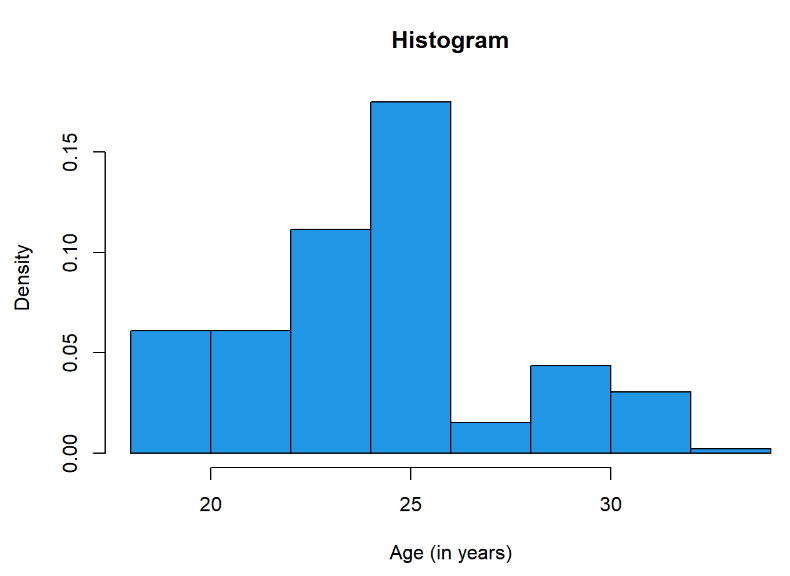

- Numeric Data
  - Box-Plots

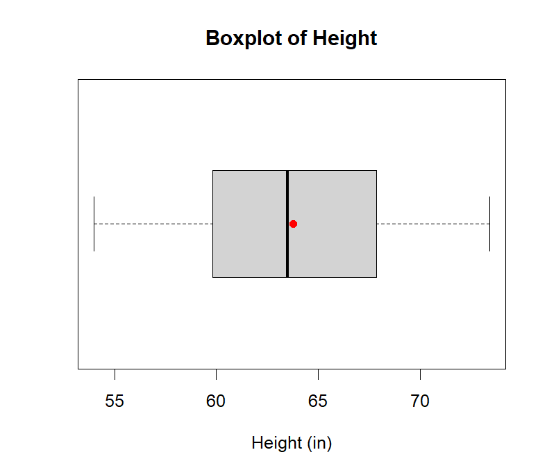

  - Stem and Leaf Plot (used for a small number of observations)
  - Dot Chart (used for a small number of observations)

### Graphical Displays: Box Plots

Boxplots show the the center, spread, and symmetry or skewness of the data. These can be plotted using the `boxplot()` function in R.

- Steps for plotting
  - Calculate the mean of your numeric variable using the `mean()` command
  - Input your variable from the dataframe object into the `boxplot()` command
    - Recall a specific variable can be extracted from a dataframe object using the `$` operator (e.g. - `dataframe$variable_name` - using the correct names for your dataframe object and variable)
  - Use the `points()` command to plot your mean along the boxplot.

#### Box Plots: Format and Example

- Format for plotting

  ```r
  # save the mean
  mean_variable <- mean(dataframe$variable,
                        na.rm=TRUE)

  # create boxplot
  boxplot(dataframe$variable,
          # Draw boxplot in Base R
          # sets boxplot to be horizontal
          # when set to TRUE
          ylab = "Variable Name (Units)",
          # x-axis label of the variable
          main = "Boxplot of Variable Name"
          # provide a title for your boxplot
          )

  # add the mean to the plot
  points(x = 1,
         # Add the mean value to the boxplot
         y = mean_variable,
         # places the point on the boxplot
         col = "red",
         # dot color for the mean
         pch = 16)
         # dot mean shape
  ```

- Example Code:

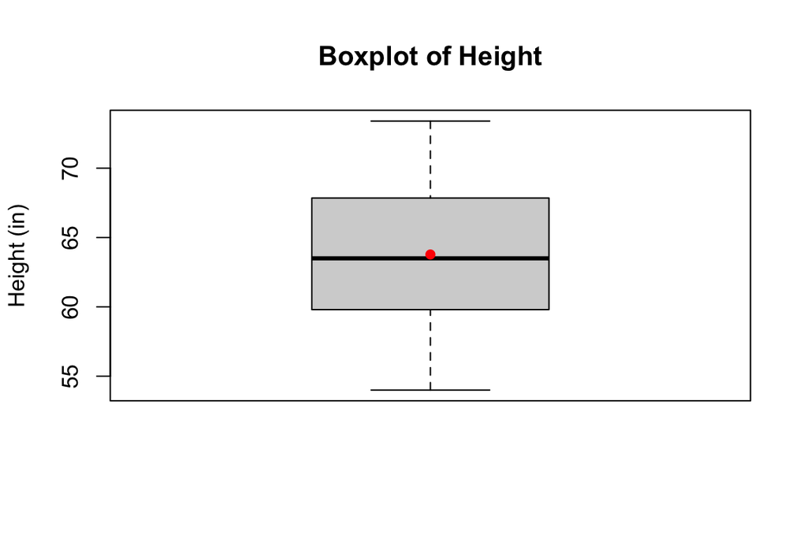

  ```r
  # save the mean of the heights
  mean_height <- mean(lab3_data_csv$height_in, na.rm=TRUE)

  # create boxplot
  boxplot(lab3_data_csv$height_in,# plot the variable
          ylab = "Height (in)", # y-axis label
          main = "Boxplot of Height") # title for your boxplot

  # add the mean to the plot
  points(x = 1, # places mean on the plot
         y = mean_height, # Add the mean to the plot
         col = "red", # dot color for the mean
         pch = 16) # dot shape for the mean
  ```

#### Box Plots: Horizontal Orientation

Box plots can also be displayed horizontally, which may be more intuitive to understand the spread and central tendency of a distribution.

- Format for plotting

  ```r
  mean_variable <- mean(dataframe$variable,
                        na.rm=TRUE)

  boxplot(dataframe$variable,
          # Draw boxplot in Base R
          horizontal = TRUE,
          # sets boxplot to be horizontal
          # when set to TRUE
          xlab = "Variable Name (Units)",
          # x-axis label of the variable
          main = "Boxplot of Variable Name")
          # provide a title for your boxplot

  points(x = mean_variable,
         # Add the mean value to the boxplot
         y = 1,
         # places the point on the boxplot
         col = "red",
         # dot color for the mean
         pch = 16)
         # dot mean shape
  ```

- Example:

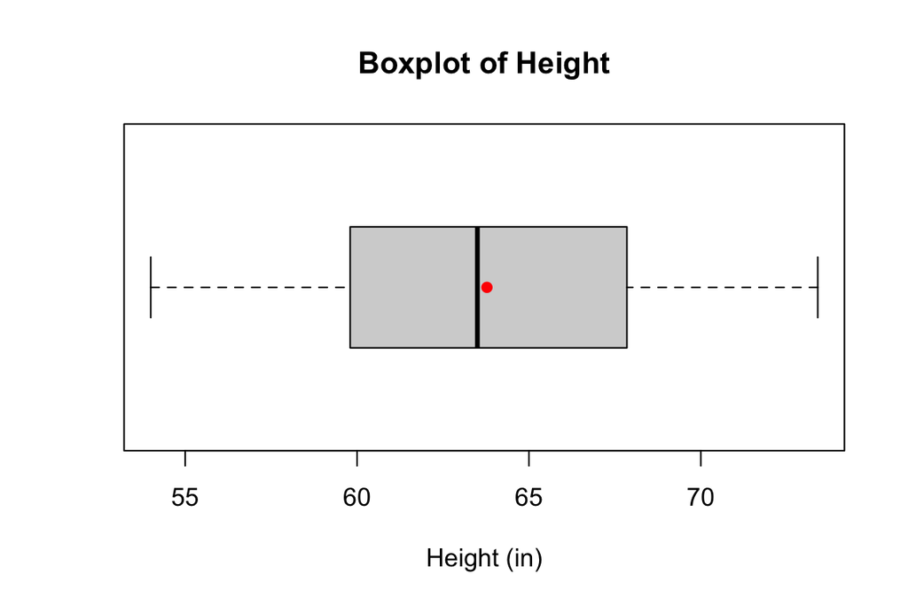

  ```r
  boxplot(lab3_data_csv$height_in, # plot height
          xlab = "Height (in)", # x-axis label
          horizontal = T,# set plot in the horizontal direction
          main = "Boxplot of Height") # add title

  points(x = mean_height, # Add the mean value to the boxplot
         y = 1, # places mean on the plot
         col = "red", pch = 16)
  ```

# Compiling a Report

**This week’s lab assignment (Lab 3) will require that you** **submit a compiled report**, not your R script (.R file). Practice compiling your R script from this week’s lab assignment.

**How to compile a report in RStudio:**

1. Remove any install.packages() statements from your script or use “#” to comment out that line of code. Reports will not compile if they include an install.packages() statement.
2. In the main menu of RStudio, click ‘File’ and then select ‘Compile Report’ OR click on the icon, as shown below:

[figure not shown]

3. Save your report as **either a HTML (.html), PDF (.pdf) or MS WORD file (.docx).** Other file types will not be accepted.
   - **Tip: Make sure that all of your code runs correctly before compiling.** For example, your report will not compile if you reference an object that has not been created in your R script or if your code contains programming errors.

# Lab Activity

Now let’s practice using a different dataset ✨

## Practice Dataset

This practice dataset, “lab3ACTScores”, is a subset of the [sat.act dataset](https://personality-project.org/r/psych/help/sat.act.html) in the [`psych` R package](https://personality-project.org/r/psych/help/00Index.html) collected as part of the [Synthetic Aperture Personality Assessment (SAPA) web based personality assessment project](https://www.sapa-project.org/).

We will only use this dataset for teaching purpose in this lab.

- There are a total of 643 observations on the following 4 variables:
  - `ACT`: ACT composite scores may range from 1 - 36. National norms have a mean of 20.
  - `age`: age of participants
  - `gender`: self-reported gender (male/female)
  - `education`: self-reported education levels (HS/finished HS/some college/college graduate/graduate degree)

## Activity 1 (Your Turn)

First, try to install and load the `Hmisc` R package. Then, import the `lab3ACTScores` dataset into R.

You can locate the dataset on Canvas in the”Lab-3” page. To find it, navigate in the Canvas course website: > Modules > Week 4 > Lab 3 Page > Scroll down to “Lab Activity Datasets” > Download either “lab3ACTScores.csv” or “lab3ACTScores.txt” using the Google Chrome web browser. It is up to you to choose either the .txt or .csv file.

💡 **Hint**: There are two steps in accessing a R package! Do you have the appropriate data types after importing dataset?

```r
# SOLUTION
## Step 1: set working directory
setwd(dir = "/Users/jane/Documents/GitHub/PSC103A/Lab3")
## Step 2: install package
install.packages("Hmisc") # comment this line out if compile report
## Step 3: load package
library("Hmisc")
## Step 4: import dataset
activity_data <- read.csv(file = "lab3ACTScores.csv", # relative path if set up working directory
                          header = T, stringsAsFactors = T)
## Step 5: check dataset
head(activity_data)
## Step 6: check data types
str(activity_data)
```

## Activity 2 (Together)

Describe `age` with measures of central tendency and variability using functions from Base R.

💡 **Hint**: Are there any missing observations in this variable? What are the measures of central tendency?

```r
# SOLUTION
## Step 1: check if have missing data
summary(activity_data$age)
## Step 2: find central measures
mean_height <- mean(activity_data$age, na.rm=TRUE)
median_height <- median(activity_data$age, na.rm=TRUE)
trimm_mean_height <- mean(activity_data$age, trim = .10, na.rm = TRUE)
## Step 3: find variability measures
range_age <- range(activity_data$age, na.rm = TRUE)
variance_age <- var(activity_data$age, na.rm = TRUE)
sd_age <- sd(activity_data$age, na.rm = TRUE)
iqr_age <- IQR(activity_data$age, na.rm = TRUE)
## Step 4: print out measure of central tendency
mean_height
median_height
trimm_mean_height
range_age
variance_age
sd_age
iqr_age
```

## Activity 3 (In Groups)

Create a graphical display that summarizes `ACT`. **Make sure to include the mean, a main title, and an axis label.** Export your work as a compiled report and save it as either a HTML, PDF or MS WORD file. Make sure to comment out any lines of code with `install.packages()`

💡 **Hint**: Are there any missing observations in this variable? What is the variable type? Which display is the most appropriate for summarizing data given the variable type?

```r
# Looking for SOLUTION?

## Think about the hints! Revisit previous slides if need to :)
## Try it out yourself!
```